# Chapter I Basics

# Chapter I Data frame operations and plotting

## Data frame operations

Data is one of the most fundamental data structures in R. We will need to be friend with it. When given the GDP data for different countries, you might probably want to only look at the countries from Asia or Africa, or you might want to compare the GDP differences between developed countries and the developing ones. In order to do so, you will need to understand how to select your data based on a certain condition and in the later session, you might want to know how to merge one data set with another in the way that you want. We now learn how to select a part of the data frame given some conditions and this is often called subletting.

### Subseting using index

```r
library(MASS)
head(Aids2)
```

```r
##   state sex  diag death status T.categ age
## 1   NSW   M 10905 11081      D      hs  35
## 2   NSW   M 11029 11096      D      hs  53
## 3   NSW   M  9551  9983      D      hs  42
## 4   NSW   M  9577  9654      D    haem  44
## 5   NSW   M 10015 10290      D      hs  39
## 6   NSW   M  9971 10344      D      hs  36
```

```r
summary(Aids2)
```

```r
##    state      sex           diag           death       status
##  NSW  :1780   F:  89   Min.   : 8302   Min.   : 8469   A:1082
##  Other: 249   M:2754   1st Qu.:10163   1st Qu.:10672   D:1761
##  QLD  : 226            Median :10665   Median :11235
##  VIC  : 588            Mean   :10584   Mean   :10990
##                        3rd Qu.:11103   3rd Qu.:11504
##                        Max.   :11503   Max.   :11504
##
##     T.categ          age
##  hs     :2465   Min.   : 0.00
##  blood  :  94   1st Qu.:30.00
##  hsid   :  72   Median :37.00
##  other  :  70   Mean   :37.41
##  id     :  48   3rd Qu.:43.00
##  haem   :  46   Max.   :82.00
##  (Other):  48
```

#### Selecting a single value

*[a,b]* is what we use to subset. a represents the row number and b represents the column number.

```r
Aids2[1,1]
```

```r
## [1] NSW
## Levels: NSW Other QLD VIC
```

```r
Aids2[1,2]
```

```r
## [1] M
## Levels: F M
```

#### Select a list of values

*1:5* will give us 1, 2, 3, 4, 5 and we are going to make use of this to select a list of values:

```r
Aids2[1, 1:5]
```

```r
##   state sex  diag death status
## 1   NSW   M 10905 11081      D
```

```r
Aids2[1:5, 1:6]
```

```r
##   state sex  diag death status T.categ
## 1   NSW   M 10905 11081      D      hs
## 2   NSW   M 11029 11096      D      hs
## 3   NSW   M  9551  9983      D      hs
## 4   NSW   M  9577  9654      D    haem
## 5   NSW   M 10015 10290      D      hs
```

### Subsetting using conditions

What if we want to look at the rows whose age is greater than 40. We can simply apply our conditional statement on age:

```r
options(max.print= 50)
Aids2$age > 40
```

```r
##  [1] FALSE  TRUE  TRUE  TRUE FALSE FALSE FALSE FALSE FALSE FALSE  TRUE
## [12] FALSE FALSE FALSE FALSE FALSE FALSE FALSE  TRUE  TRUE FALSE FALSE
## [23] FALSE FALSE  TRUE FALSE FALSE FALSE FALSE FALSE FALSE FALSE FALSE
## [34] FALSE FALSE FALSE  TRUE FALSE FALSE FALSE  TRUE FALSE  TRUE FALSE
## [45] FALSE FALSE  TRUE  TRUE FALSE FALSE
##  [ reached getOption("max.print") -- omitted 2793 entries ]
```

Then we know logical vectors can select the values we need, and it suffices to do

```r
Aids2[Aids2$age > 40, ]
```

```r
##      state sex  diag death status T.categ age
## 2      NSW   M 11029 11096      D      hs  53
## 3      NSW   M  9551  9983      D      hs  42
## 4      NSW   M  9577  9654      D    haem  44
## 11     NSW   M 10416 10432      D      hs  45
## 19     NSW   M 10993 11504      A      hs  56
## 20     NSW   M 11020 11171      D      hs  41
## 25     NSW   M 10885 11196      D      hs  46
##  [ reached getOption("max.print") -- omitted 975 rows ]
```

## Plotting

Here we will do a few simple plottings:

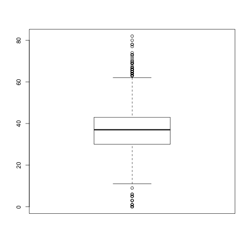

```r
boxplot(Aids2$age)
```

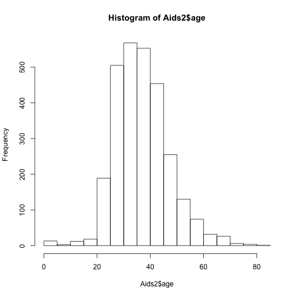

```r
hist(Aids2$age)
```

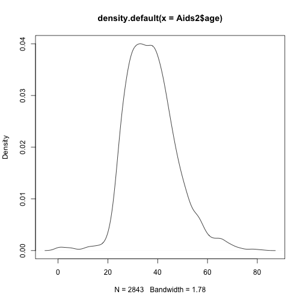

```r
dens <- density(Aids2$age)
plot(dens)
```

Then often we will combine our plotting with subsetting to get the wanted analysis. For example, we want to know the sex distribution of people who are over 40. We first do a subsetting and then plot the distribution:

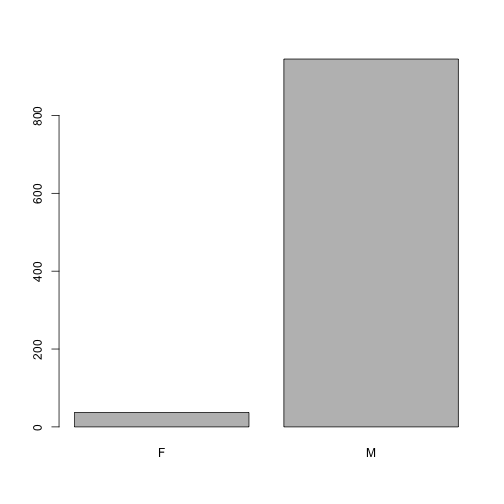

```r
fortyPlus <- Aids2[Aids2$age > 40, ]
plot(fortyPlus$sex)
```